# Data Analysis of Week 3 Example Data

Priscilla Cuellar-Rocha

2023-07-26

## Overview

This report presents primary data analysis for the Week 3 example data. Specifically, this will report basic descriptive statistics as well as report tests of the following predictions:

1. People will feel more guilt when:
- 1.1. They caused the shock (vs. their partner)
- 1.2. The partner is morally good (vs. bad)
- 1.3. The shock is stronger (high > medium > low)
2. Women will report more guilt than men
3. Agreeable people will report more guilt
4. Neurotic people will report more guilt

and

5. People will be more generous when:
- 5.1 They caused the shock (vs. their partner)
- 5.2 The partner is morally good (vs. bad)
- 5.3 The shock is stronger (high > medium > low)
6. Women will be more generous than men
7. Agreeable people will be more generous
8. Neurotic people will be more generous

```r
#Load in the data
data<-read.csv("Week 3/Processed Data/Week 3 Data PROCESSED.csv")

#Recode variables:
data$PIN<-as.factor(data$PIN)
data$sex<-as.factor(data$sex)
data$shock<-as.factor(data$shock)
data$shockCause<-as.factor(data$shockCause)
data$pMoral<-as.factor(data$pMoral)
```

## Descriptives

Descriptive statistics for guilt:

```r
c(summary(data$guilt),"SD"=sd(data$guilt,na.rm=T))
```

```
##     Min.  1st Qu.   Median     Mean  3rd Qu.     Max.     NA's       SD
## 1.000000 3.000000 4.000000 3.998601 5.000000 7.000000 5.000000 1.280646
```

Descriptive statistics for generosity:

```r
#Pre-shock:
c(summary(data$preShare),"SD"=sd(data$preShare,na.rm=T))
```

```
##     Min.  1st Qu.   Median     Mean  3rd Qu.     Max.       SD
## 1.000000 3.000000 4.000000 3.979167 5.000000 7.000000 1.036663
```

```r
#Post-shock:
c(summary(data$postShare),"SD"=sd(data$postShare,na.rm=T))
```

```
##      Min.   1st Qu.    Median      Mean   3rd Qu.      Max.        SD
##  0.000000  2.000000  4.000000  4.272222  6.000000 10.000000  2.531758
```

Descriptive statistics for personality:

```r
#Agreeableness:
c(summary(data$agre),"SD"=sd(data$agre,na.rm=T))
```

```
##     Min.  1st Qu.   Median     Mean  3rd Qu.     Max.       SD
## 1.000000 3.000000 4.000000 3.903472 4.500000 7.000000 1.131507
```

```r
#Neuroticism:
#Pre-shock:
c(summary(data$neuro),"SD"=sd(data$neuro,na.rm=T))
```

```
##     Min.  1st Qu.   Median     Mean  3rd Qu.     Max.       SD
## 1.000000 3.000000 3.500000 3.738889 4.500000 7.000000 1.006869
```

## Guilt Analyses

### Prediction 1.1

Prediction 1.1 was supported. People felt more guilty when they caused the shock:

```r
#Run the t-test for prediction 1.1
p1.1<-t.test(data$guilt~data$shockCause)

#Output the result
p1.1
```

```
##
##  Welch Two Sample t-test
##
## data:  data$guilt by data$shockCause
## t = -11.016, df = 708.25, p-value < 2.2e-16
## alternative hypothesis: true difference in means between group 0 and group 1 is not equal to 0
## 95 percent confidence interval:
##  -1.1502070 -0.8022365
## sample estimates:
## mean in group 0 mean in group 1
##        3.511173        4.487395
```

```r
plot1.1 <- ggplot(data=data,aes(x=shockCause, y=guilt, fill = shockCause)) +
  labs(x= "Cause of Shock",
       y= "Guilt") +
  stat_summary(fun = "mean",
               geom = "bar",
               position = "dodge") +
  stat_summary(fun.data = "mean_cl_boot",
               geom = "errorbar",
               position = "dodge") +
  #this will bootstrap (estimate) what the errors should be
  scale_x_discrete(labels=c("Partner Inflict","Self Inflict")) +
  scale_fill_manual(values=c("purple2",  "pink"),
                    guide=F) +
  theme_grey(base_size=20)


colors()
```

[output not shown]

[output cut: 204 more lines]

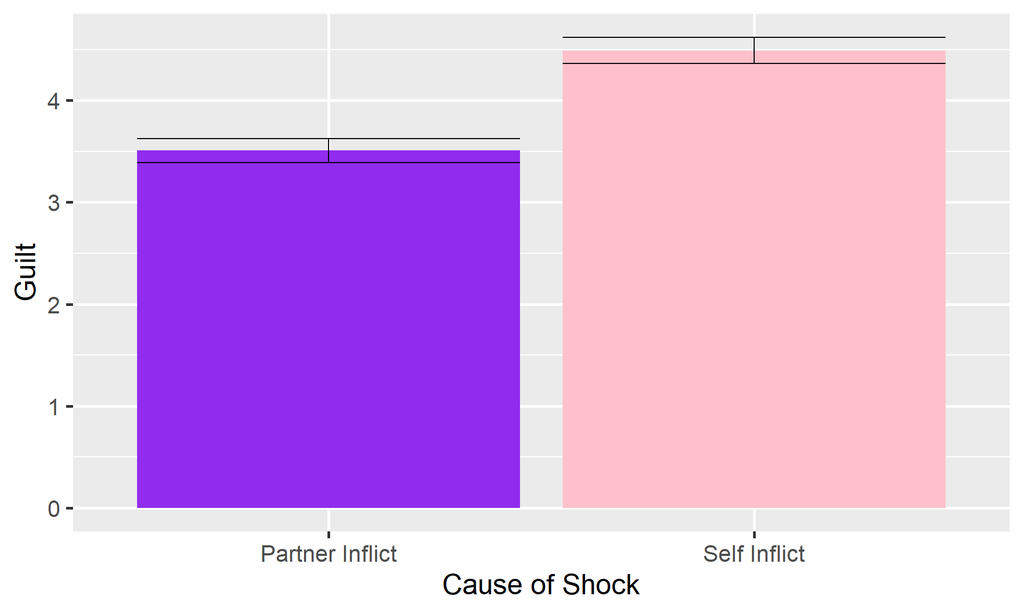

```r
#Output the graph

plot1.1
```

### Prediction 1.2

Prediction 1.2 was supported. People felt more guilty when the partner was morally good:

```r
#Run the t-test for prediction 1.2
p1.2<-t.test(data$guilt~data$pMoral)


#Output the result
p1.2
```

```
##
##  Welch Two Sample t-test
##
## data:  data$guilt by data$pMoral
## t = -19.802, df = 707.28, p-value < 2.2e-16
## alternative hypothesis: true difference in means between group 0 and group 1 is not equal to 0
## 95 percent confidence interval:
##  -1.675632 -1.373333
## sample estimates:
## mean in group 0 mean in group 1
##        3.235294        4.759777
```

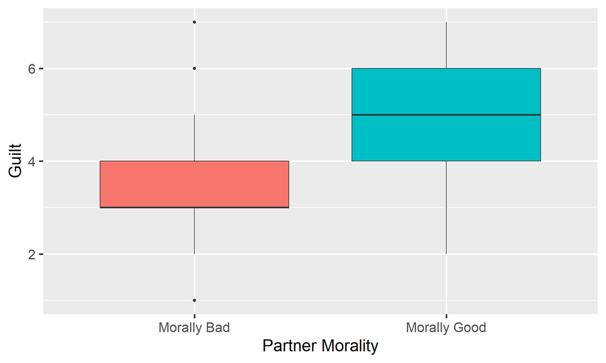

```r
plot1.2 <- ggplot(data=data,
                  aes(x=pMoral,
                      y=guilt,
                      fill = pMoral)) +
  labs(x="Partner Morality", y="Guilt") +
  scale_x_discrete(labels=c("Morally Bad", "Morally Good")) +
  theme_gray(base_size=20) +
  guides(fill=F) +
  geom_boxplot()
plot1.2
```

### Prediction 1.3

Prediction 1.3 was supported. People felt more guilty when the shock was stronger:

```r
#Run the ANOVA for prediction 1.3
p1.3<-lm(guilt~shock,data=data)

#Output the result
anova(p1.3)
```

```
## Analysis of Variance Table
##
## Response: guilt
##            Df Sum Sq Mean Sq F value    Pr(>F)
## shock       2 193.85  96.927  70.626 < 2.2e-16 ***
## Residuals 712 977.14   1.372
## ---
## Signif. codes:  0 '***' 0.001 '**' 0.01 '*' 0.05 '.' 0.1 ' ' 1
```

```r
#Output the group means
tapply(data$guilt,data$shock,function(x) mean(x,na.rm=T))
```

```
##        0        1        2
## 3.350211 4.012605 4.625000
```

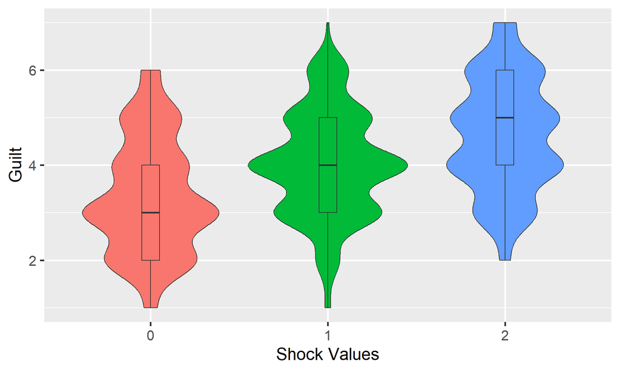

```r
#Generate the plot

plot1.3 <- ggplot(data=data,
                  aes(x=shock,
                      y=guilt,
                      fill=shock)) +
  labs(x = "Shock Values", y="Guilt") +
  scale_shape_discrete(labels=c("Low","Medium","High")) +
  theme_gray(base_size=20) +
  guides(fill = F) +
  geom_violin(position=position_dodge(.9))+
  geom_boxplot(position=position_dodge(.9),
                             width=.1)

plot1.3
```

### Prediction 2

Prediction 2 was not supported. Women did not report more guilt than men:

```r
#Run the t-test for prediction 2
p2<-t.test(data$guilt~data$sex)

#Output the result
p2
```

```
##
##  Welch Two Sample t-test
##
## data:  data$guilt by data$sex
## t = 0.61306, df = 711.59, p-value = 0.54
## alternative hypothesis: true difference in means between group 0 and group 1 is not equal to 0
## 95 percent confidence interval:
##  -0.1293834  0.2468740
## sample estimates:
## mean in group 0 mean in group 1
##        4.027933        3.969188
```

### Prediction 3

Prediction 3 was supported. Agreeable people reported more guilt:

```r
#Run the correlation test for prediction 3
p3<-cor.test(data$agre,data$guilt)

#Output the result
p3
```

```
##
##  Pearson's product-moment correlation
##
## data:  data$agre and data$guilt
## t = 4.3382, df = 713, p-value = 1.644e-05
## alternative hypothesis: true correlation is not equal to 0
## 95 percent confidence interval:
##  0.08807907 0.23096956
## sample estimates:
##       cor
## 0.1603644
```

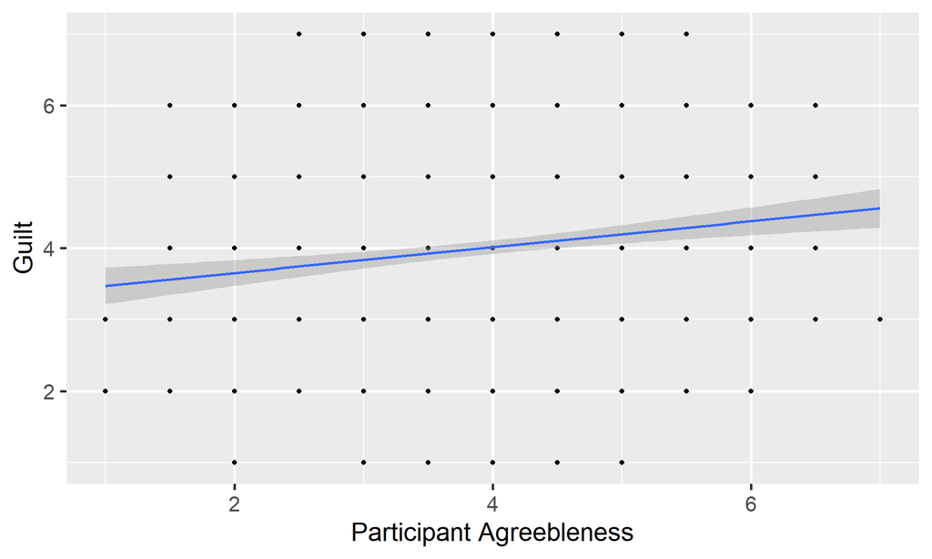

```r
#Plot a linear model

plot3 <- ggplot(data=data,
                aes(x=agre,
                    y=guilt)) +
  labs(x="Participant Agreebleness",
       y="Guilt") +
  theme_gray(base_size = 20) +
  geom_point() +
  geom_smooth(method=lm)

plot3
```

### Prediction 4

Prediction 4 was not supported. There was no relationship between neuroticism and guilt:

```r
#Run the correlation test for prediction 4
p4<-cor.test(data$neuro,data$guilt)

#Output the result
p4
```

```
##
##  Pearson's product-moment correlation
##
## data:  data$neuro and data$guilt
## t = -0.10897, df = 713, p-value = 0.9133
## alternative hypothesis: true correlation is not equal to 0
## 95 percent confidence interval:
##  -0.07737873  0.06926072
## sample estimates:
##         cor
## -0.00408094
```

```r
#Test predictions 3 and 4 in a regression:
guiltReg<-lm(guilt~neuro+agre,data=data)
summary(guiltReg)
```

```
##
## Call:
## lm(formula = guilt ~ neuro + agre, data = data)
##
## Residuals:
##     Min      1Q  Median      3Q     Max
## -3.1970 -0.9266 -0.0161  0.8942  3.2547
##
## Coefficients:
##               Estimate Std. Error t value Pr(>|t|)
## (Intercept)  3.2939882  0.2469202  13.340  < 2e-16 ***
## neuro       -0.0004411  0.0469905  -0.009    0.993
## agre         0.1809629  0.0417565   4.334 1.68e-05 ***
## ---
## Signif. codes:  0 '***' 0.001 '**' 0.01 '*' 0.05 '.' 0.1 ' ' 1
##
## Residual standard error: 1.266 on 712 degrees of freedom
##   (5 observations deleted due to missingness)
## Multiple R-squared:  0.02572,    Adjusted R-squared:  0.02298
## F-statistic: 9.397 on 2 and 712 DF,  p-value: 9.374e-05
```

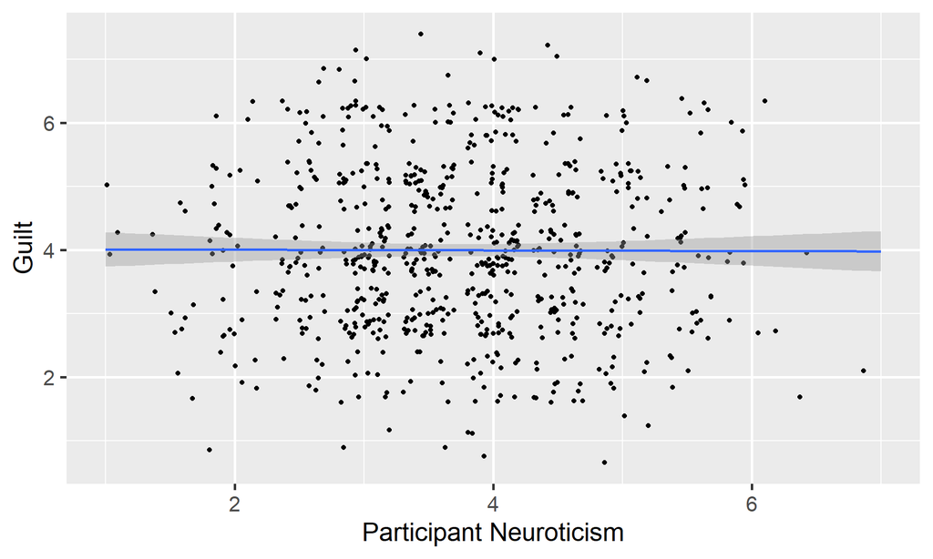

```r
#Graph
plot4 <- ggplot(data=data,
                aes(x=neuro,
                    y=guilt)) +
  labs(x="Participant Neuroticism",
       y="Guilt") +
  theme_gray(base_size = 20) +
  geom_jitter() +
  geom_smooth(method=lm)

plot4
```

## Generosity Analyses

```r
#Melt the data for within-subjects analyses
dataMelt<-melt(data,
               measure.vars=c("preShare","postShare"),
               variable.name=c("prePost"),
               value.name=c("share"))
```

### Prediction 5.1 - Two Way Anova

Prediction 5.1 was supported. People were more generous when they caused the shock:

```r
#Run the within-subjects ANOVA for p5.1
p5.1<-aov(share~prePost*shockCause+Error(PIN),data=dataMelt)

#Output the results:
summary(p5.1)
```

```
##
## Error: PIN
##             Df Sum Sq Mean Sq F value Pr(>F)
## shockCause   1  601.9   601.9   156.5 <2e-16 ***
## Residuals  718 2761.8     3.8
## ---
## Signif. codes:  0 '***' 0.001 '**' 0.01 '*' 0.05 '.' 0.1 ' ' 1
##
## Error: Within
##                     Df Sum Sq Mean Sq F value  Pr(>F)
## prePost              1   30.9    30.9   14.96 0.00012 ***
## prePost:shockCause   1  534.1   534.1  258.51 < 2e-16 ***
## Residuals          718 1483.5     2.1
## ---
## Signif. codes:  0 '***' 0.001 '**' 0.01 '*' 0.05 '.' 0.1 ' ' 1
```

```r
#Output means as a function of condition:
tapply(dataMelt$share,dataMelt[,c(23,20)],function(x) mean(x,na.rm=T))
```

```
##            shockCause
## prePost            0        1
##   preShare  3.941667 4.016667
##   postShare 3.016667 5.527778
```

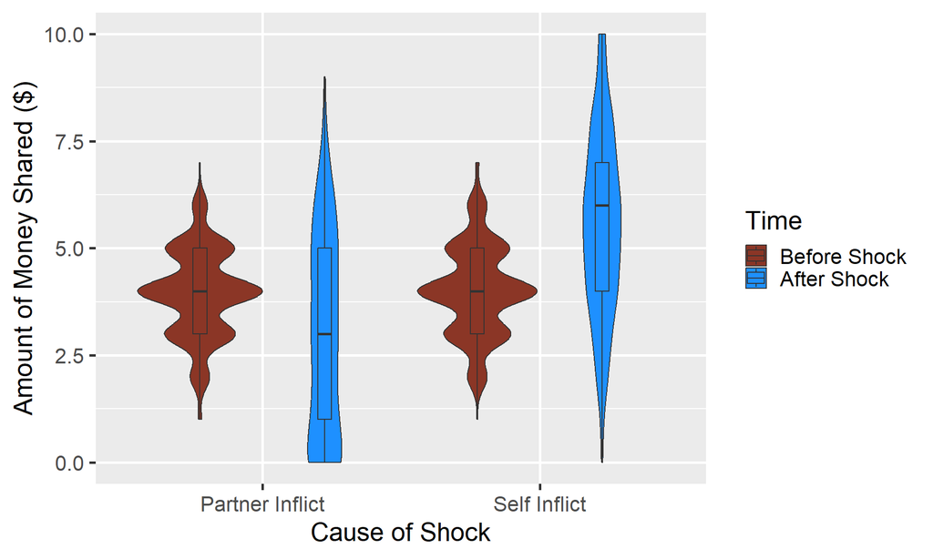

```r
#Graph

plot5 <- ggplot(data=dataMelt,
                aes(x=shockCause,
                    y=share,
                    fill=prePost)) +
  labs(x="Cause of Shock", y="Amount of Money Shared ($)", fill="Time") +
  theme_gray(base_size=20) +
  scale_x_discrete(labels = c("Partner Inflict", "Self Inflict")) +
  scale_fill_manual(values=c("tomato4", "dodgerblue"  ),
                    labels = c("Before Shock",
                               "After Shock")) +
    geom_violin(position = position_dodge(.9)) +
    geom_boxplot(position = position_dodge(.9),
                 width=.1)

plot5
```

### Prediction 5.2

Prediction 5.2 was supported. People were more generous when the partner was morally good:

```r
#Run the within-subjects ANOVA for p5.2
p5.2<-aov(share~prePost*pMoral+Error(PIN),data=dataMelt)

#Output the results:
summary(p5.2)
```

```
##
## Error: PIN
##            Df Sum Sq Mean Sq F value Pr(>F)
## pMoral      1  872.7   872.7   251.5 <2e-16 ***
## Residuals 718 2491.1     3.5
## ---
## Signif. codes:  0 '***' 0.001 '**' 0.01 '*' 0.05 '.' 0.1 ' ' 1
##
## Error: Within
##                 Df Sum Sq Mean Sq F value   Pr(>F)
## prePost          1   30.9    30.9   22.52 2.51e-06 ***
## prePost:pMoral   1 1031.9  1031.9  751.69  < 2e-16 ***
## Residuals      718  985.7     1.4
## ---
## Signif. codes:  0 '***' 0.001 '**' 0.01 '*' 0.05 '.' 0.1 ' ' 1
```

```r
#Output means as a function of condition:
tapply(dataMelt$share,dataMelt[,c(23,21)],function(x) mean(x,na.rm=T))
```

```
##            pMoral
## prePost            0        1
##   preShare  4.047222 3.911111
##   postShare 2.647222 5.897222
```

### Prediction 5.3

Prediction 5.3 was supported. People were more generous when the shock was stronger:

```r
#Run the within-subjects ANOVA for p5.3
p5.3<-aov(share~prePost*shock+Error(PIN),data=dataMelt)

#Output the results:
summary(p5.3)
```

```
##
## Error: PIN
##            Df Sum Sq Mean Sq F value   Pr(>F)
## shock       2  277.4   138.7   32.23 3.97e-14 ***
## Residuals 717 3086.3     4.3
## ---
## Signif. codes:  0 '***' 0.001 '**' 0.01 '*' 0.05 '.' 0.1 ' ' 1
##
## Error: Within
##                Df Sum Sq Mean Sq F value   Pr(>F)
## prePost         1   30.9   30.92   12.32 0.000476 ***
## prePost:shock   2  218.5  109.25   43.54  < 2e-16 ***
## Residuals     717 1799.1    2.51
## ---
## Signif. codes:  0 '***' 0.001 '**' 0.01 '*' 0.05 '.' 0.1 ' ' 1
```

```r
#Output means as a function of condition:
tapply(dataMelt$share,dataMelt[,c(23,19)],function(x) mean(x,na.rm=T))
```

```
##            shock
## prePost            0      1        2
##   preShare  3.891667 4.0375 4.008333
##   postShare 3.233333 4.3250 5.258333
```

### Prediction 6

Prediction 6 was not supported. Women were not more generous:

```r
#Run the ANOVA to test prediction 6
p6<-aov(share~prePost*sex+Error(PIN),data=dataMelt)

#Output the results:
summary(p6)
```

```
##
## Error: PIN
##            Df Sum Sq Mean Sq F value Pr(>F)
## sex         1      0   0.001       0   0.99
## Residuals 718   3364   4.685
##
## Error: Within
##              Df Sum Sq Mean Sq F value   Pr(>F)
## prePost       1   30.9  30.917   11.00 0.000955 ***
## prePost:sex   1    0.1   0.084    0.03 0.862756
## Residuals   718 2017.5   2.810
## ---
## Signif. codes:  0 '***' 0.001 '**' 0.01 '*' 0.05 '.' 0.1 ' ' 1
```

```r
#Output means as a function of condition and sex:
tapply(dataMelt$share,dataMelt[,c(23,2)],function(x) mean(x,na.rm=T))
```

```
##            sex
## prePost            0        1
##   preShare  3.972222 3.986111
##   postShare 4.280556 4.263889
```

### Prediction 7

Prediction 7 was supported. Agreeable people were more generous:

```r
#Run the correlation test for prediction 7
p7<-cor.test(data$agre,data$postShare)

#Output the result
p7
```

```
##
##  Pearson's product-moment correlation
##
## data:  data$agre and data$postShare
## t = 2.9172, df = 718, p-value = 0.003643
## alternative hypothesis: true correlation is not equal to 0
## 95 percent confidence interval:
##  0.03544253 0.17987139
## sample estimates:
##      cor
## 0.108228
```

### Prediction 8

Prediction 8 was not supported. There was no relationship between neuroticism and generosity:

```r
#Run the correlation test for prediction 8
p8<-cor.test(data$neuro,data$postShare)

#Output the result
p8
```

```
##
##  Pearson's product-moment correlation
##
## data:  data$neuro and data$postShare
## t = -0.09243, df = 718, p-value = 0.9264
## alternative hypothesis: true correlation is not equal to 0
## 95 percent confidence interval:
##  -0.07649589  0.06963389
## sample estimates:
##          cor
## -0.003449418
```

```r
#Test predictions 7 and 8 in a regression:
genReg<-lm(postShare~neuro+agre,data=data)
summary(genReg)
```

```
##
## Call:
## lm(formula = postShare ~ neuro + agre, data = data)
##
## Residuals:
##     Min      1Q  Median      3Q     Max
## -4.7816 -1.9557  0.1881  1.8237  5.8297
##
## Coefficients:
##              Estimate Std. Error t value Pr(>|t|)
## (Intercept)  3.336106   0.491063   6.794  2.3e-11 ***
## neuro       -0.002397   0.093378  -0.026  0.97953
## agre         0.242112   0.083093   2.914  0.00368 **
## ---
## Signif. codes:  0 '***' 0.001 '**' 0.01 '*' 0.05 '.' 0.1 ' ' 1
##
## Residual standard error: 2.52 on 717 degrees of freedom
## Multiple R-squared:  0.01171,    Adjusted R-squared:  0.008957
## F-statistic: 4.249 on 2 and 717 DF,  p-value: 0.01464
```